# HW3

ShibeiXu

2021/10/19

## Question 1

### Short Description

there are 15 variables and 1384617 observations in this dataset. It contains details including `user id`: customer identifier, `order id`: order identifier, `product id`: product identifier, `product name`, `reordered` if it is reordered or not. Also, in the local store, there are 21 departments.

### Answers to question

1.There are 134 aisles in the store. And among them, “fresh vegetables” ordered the most.

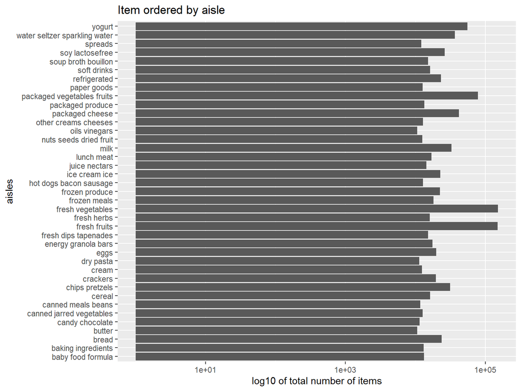

```r
instacart %>%
  group_by(aisle) %>%
  summarize(n_obs = n())%>%
  filter(n_obs>10000)%>%
  ggplot(aes(x = aisle,y=n_obs)) +
  geom_bar(stat='identity') +
  scale_y_log10() +
  labs(x = "aisles",
       y = "log10 of total number of items",
       title = "Item ordered by aisle") +
  coord_flip()
```

3.

```r
instacart %>%
  filter(aisle %in% c("baking ingredients", "dog food care", "packaged vegetables fruits")) %>%
  group_by(aisle, product_name) %>%
  summarise(item_sum = n()) %>%
  group_by(aisle) %>%
  mutate(item_rank = min_rank(desc(item_sum))) %>%
  filter(item_rank == 1) %>%
  knitr::kable(digits = 1)
```

| aisle | product_name | item_sum | item_rank |
| --- | --- | --- | --- |
| baking ingredients | Light Brown Sugar | 499 | 1 |
| dog food care | Snack Sticks Chicken & Rice Recipe Dog Treats | 30 | 1 |
| packaged vegetables fruits | Organic Baby Spinach | 9784 | 1 |

```r
instacart %>%
  filter(product_name %in% c("Pink Lady Apples", "Coffee Ice Cream")) %>%
  select(product_name, order_dow, order_hour_of_day) %>%
  group_by(product_name, order_dow) %>%
  summarise(mean_hour = mean(order_hour_of_day)) %>%
  spread(key = order_dow, value = mean_hour) %>%
  rename(Sunday = "0", Monday = "1", Tuesday = "2", Wednesday = "3", Thursday = "4", Friday = "5", Saturday = "6") %>%
  knitr::kable(digit = 1)
```

| product_name | Sunday | Monday | Tuesday | Wednesday | Thursday | Friday | Saturday |
| --- | --- | --- | --- | --- | --- | --- | --- |
| Coffee Ice Cream | 13.8 | 14.3 | 15.4 | 15.3 | 15.2 | 12.3 | 13.8 |
| Pink Lady Apples | 13.4 | 11.4 | 11.7 | 14.2 | 11.6 | 12.8 | 11.9 |

### Question 2

```r
library(p8105.datasets)
library(tidyverse)
library(patchwork)
data("brfss_smart2010")
```

Answers to question 2

1. CT, FL, MA, NC, NJ, PA states were observed at least 7 locations in 2002.CA, CO, FL, MA, MD, NC, NE, NJ, NY, OH, PA, SC, TX, WAstates were observed at least 7 locations in 2010

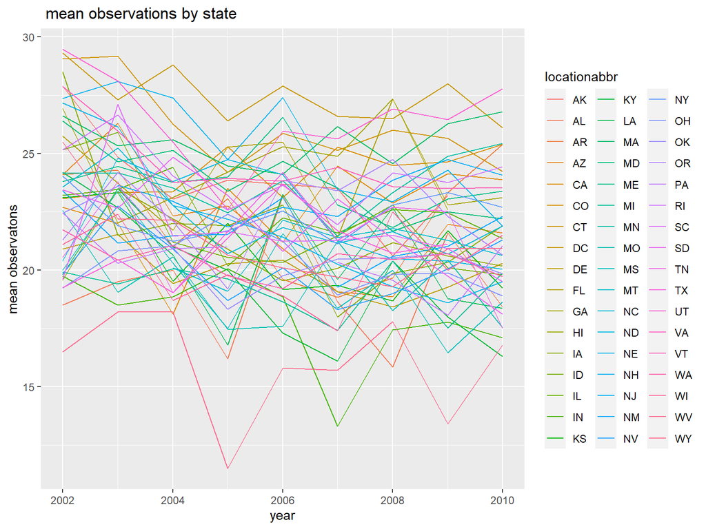

```r
brfss %>%
  filter(response=="Excellent")%>%
  group_by(year, locationabbr) %>%
  summarise(mean_value = mean(data_value)) %>%
  ggplot(aes(x = year, y = mean_value, group = locationabbr, color = locationabbr)) +
  geom_line() +
  labs(
    y = "mean observatons",
    title = " mean observations by state"
  )
```

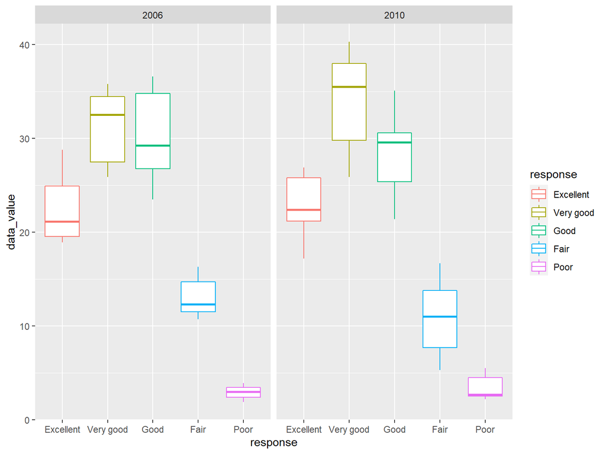

```r
brfss %>%
  filter(year %in% c("2006","2010"), locationabbr == "NY") %>%
  ggplot(aes(x=response,y=data_value,color=response))+
  geom_boxplot()+
  facet_grid(.~year)
```

### Question 3 1.

```r
accel=read_csv("accel_data.csv")%>%
  janitor::clean_names()%>%
  pivot_longer(activity_1:activity_1440,names_to = "activitiy_day",values_to = "activity_counts")%>%
  mutate(daytype=ifelse(day=="Sunday"|day=="Saturday","weekend","weekday"))%>%
  mutate(activity_counts=as.integer(activity_counts))
```

there are 6 variables and 50400 observations in this dataset. It contains details including `week`: week identifier, `day id`: date identifier, `daytype`: identify if it is weekday(Monday to Friday) or weekend (Saturday to Sunday). The original activity is pivot into `activity_counts`and `activity_day` .

```r
accel%>%
group_by(day)%>%
summarize(total=sum(activity_counts))%>%
knitr::kable(digits = 1)
```

| day | total |
| --- | --- |
| Friday | 2291448 |
| Monday | 1858545 |
| Saturday | 1369237 |
| Sunday | 1919213 |
| Thursday | 2090445 |
| Tuesday | 1798521 |
| Wednesday | 2129059 |

The activity in Wednesday and Friday is significantly higher than the activity counts in Saturday.

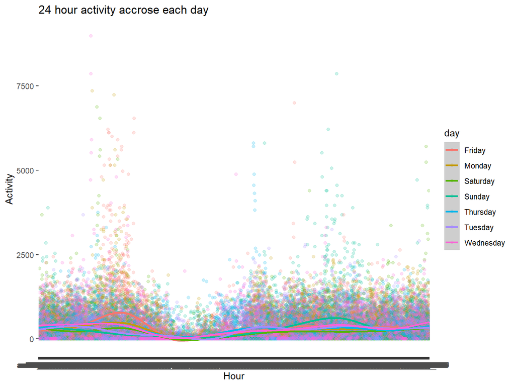

```r
accel%>%
  ggplot(aes(x=activitiy_day,y=activity_counts,color=day))+
  geom_point(alpha=.2)+
  geom_smooth(aes(group=day))+
  labs(
    title="24 hour activity accrose each day",
    x="Hour",
    y="Activity")
```